# Howard - Good/Bad Plot

Kristen Howard

2023-03-30

# Introduction

Today we will be using previous TidyTuesday data containing data regarding Cocktails. First, load up the packages. This data contains information on popular cocktails, different categories, and much more!

# Load Packages

```r
library(here)
library(tidyverse)
library(lubridate)
library(dplyr)
library(imager)
library(jpeg)
library(magick)
library(ggpattern)
library(RColorBrewer)
```

### load the data

```r
cocktails <- readr::read_csv('https://raw.githubusercontent.com/rfordatascience/tidytuesday/master/data/2020/2020-05-26/cocktails.csv')
glimpse(cocktails)
```

```
## Rows: 2,104
## Columns: 13
## $ row_id            <dbl> 0, 0, 1, 1, 1, 1, 1, 1, 1, 1, 2, 2, 3, 3, 3, 3, 3, 3…
## $ drink             <chr> "'57 Chevy with a White License Plate", "'57 Chevy w…
## $ date_modified     <dttm> 2016-07-18 22:49:04, 2016-07-18 22:49:04, 2016-07-1…
## $ id_drink          <dbl> 14029, 14029, 15395, 15395, 15395, 15395, 15395, 153…
## $ alcoholic         <chr> "Alcoholic", "Alcoholic", "Alcoholic", "Alcoholic", …
## $ category          <chr> "Cocktail", "Cocktail", "Shot", "Shot", "Shot", "Sho…
## $ drink_thumb       <chr> "http://www.thecocktaildb.com/images/media/drink/qyy…
## $ glass             <chr> "Highball glass", "Highball glass", "Old-fashioned g…
## $ iba               <chr> NA, NA, NA, NA, NA, NA, NA, NA, NA, NA, NA, NA, NA, …
## $ video             <lgl> NA, NA, NA, NA, NA, NA, NA, NA, NA, NA, NA, NA, NA, …
## $ ingredient_number <dbl> 1, 2, 1, 2, 3, 4, 5, 6, 7, 8, 1, 2, 1, 2, 3, 4, 5, 6…
## $ ingredient        <chr> "Creme de Cacao", "Vodka", "Absolut Kurant", "Grand …
## $ measure           <chr> "1 oz white", "1 oz", "1/2 oz", "1/4 oz", "1/4 oz", …
```

```r
view(cocktails)
```

### Add an Image

Now, Let’s create our Bad graph! We want to add in an image in our background, so let’s load in that image.

```r
img <- image_read("https://images.unsplash.com/photo-1597290282695-edc43d0e7129?ixlib=rb-4.0.3&ixid=MnwxMjA3fDB8MHxwaG90by1wYWdlfHx8fGVufDB8fHx8&auto=format&fit=crop&w=875&q=80")
# This is how you add in image

img %>% # Scale the image to make it fill the screen
  image_scale("200")
```

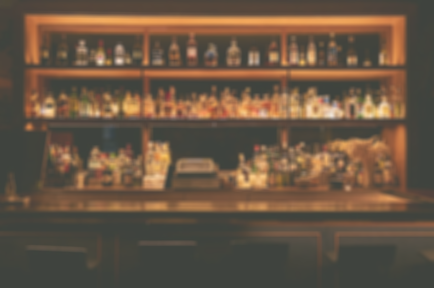

```r
img %>% # Blur the image for a dramatic effect and put a white haze on it
  image_blur(5, 5) %>%
  image_colorize(opacity = 20, color = "white")
```

### Subset the data and create graph

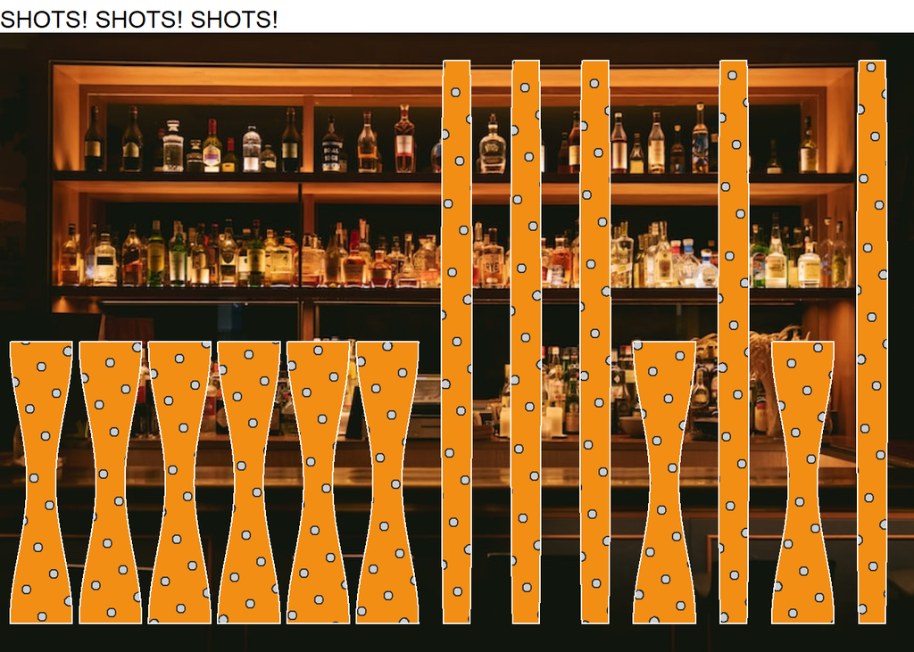

```r
cocktails_clean <- cocktails %>% #Subset data to the variables of interest
  select(drink, ingredient_number,category,drink_thumb) %>%
  filter(category == 'Beer',
         ingredient_number < 4)

view(cocktails_clean) # check subsetted data


cocktails_clean %>%
  ggplot( aes(x = ingredient_number,
              y = drink)) +
  annotation_custom(grid::rasterGrob(img # This grid replaced the usual panel.
                                     , width = unit(1, "npc")
                                     , height = unit(1, "npc"))) +
  geom_violin_pattern( fill = '#f28e13', color = 'white',
                       pattern = 'circle', pattern_density = 0.3) +
  coord_flip() +
  labs(title = 'SHOTS! SHOTS! SHOTS!') +
  theme(titl = element_text(angle = -45, hjust = 0)) +
  theme(axis.text.x = element_text(colour = "#FF10F0")) +
  theme(panel.background = element_rect(fill = 'img'))+
  theme_void()
```

This chart is **bad** because there is NO indication on what is being measured on the x and y axis. Additionally, there are some major aesthetic issues. While there is a [title](https://www.youtube.com/watch?v=yNju8Rgwtg8), it is not centered and not enough information is given. Now you can enjoy a nice tall glass of beer!

Now, let’s look at the good chart

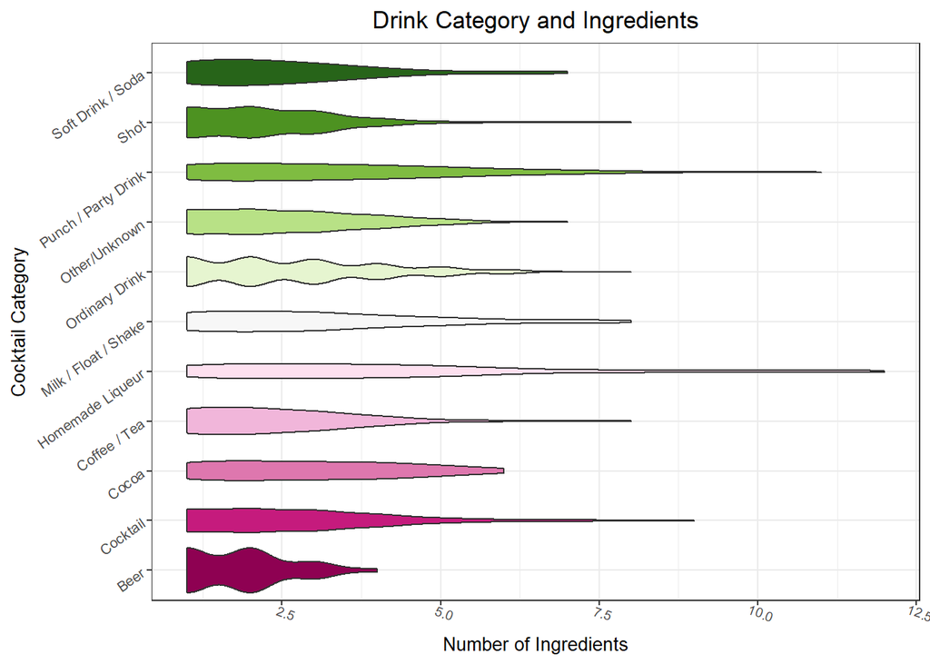

```r
cocktails %>%
  ggplot( aes(x = category,
              y = ingredient_number,
              fill = category)) +
  geom_violin() +
  theme_bw() +
  scale_fill_brewer(palette = "PiYG") +
  ggtitle(label = "Drink Category and Ingredients") +
  labs( x = "Cocktail Category",
        y = "Number of Ingredients") +
  theme(legend.position="none",
        plot.title = element_text(hjust = 0.5),
        axis.text.y = element_text(angle = 35, size = 8),
        axis.text.x = element_text(angle = -20, vjust = -0.3, size = 7),
        axis.title.x = element_text(size=10),
        axis.title.y = element_text(size=10)) +
  coord_flip()
```

This chart is **good** because there are clean labels on the x and y axis. This chart has broken down the the categories seen in this data set and is comparing the number of ingredients seen in each category. There is a clear label that is centered and there are no distracting colors to take away from the graph.